# FACTORES QUE INFLUYERON EN EL RENDIMIENTO ACADÉMICO DE LOS ESTUDIANTES DE LA UTEC EN EL PERÍODO 2022-2

31 Agosto, 2023

## I. INTRODUCCIÓN

*El desempeño académico de un estudiante universitario puede verse afectado por un conjunto de factores en su entorno, el presente estudio se enfoca en la identificación y análisis del impacto de estos factores sobre su desempeño académico, generando información que será útil para la toma de decisiones que contribuyan a mejorar este desempeño.*

### - Relevancia:

*Elegimos este tema debido a que es interesante reconocer los factores que influyen en el rendimiento de los estudiantes, al permitir una mejor comprensión de cómo estos pueden afectar de diferentes maneras ya sea, física o psicológicamente en los estudiantes. Asimismo nos puede ayudar en el desarrollo de habilidades y estrategias para mejorar el rendimiento académico y alcanzar los objetivos deseados. Por ello nos gustaría saber si la opinión de los estudiantes de la UTEC a través de una encuesta puede ser útil para la universidad y los educadores para adaptar sus programas y servicios en función de las necesidades de los estudiantes, lo que puede mejorar el desempeño académico de los estudiantes y su bienestar en general.*

### - Planeamiento del proyecto

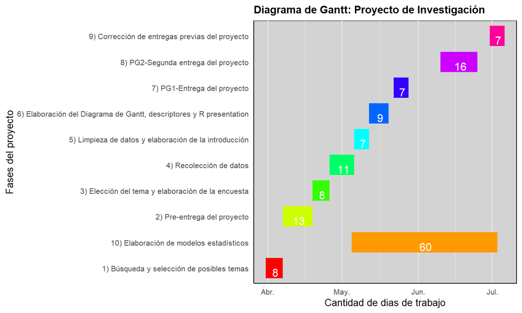

## II. OBJETIVOS

## - Objetivo General:

**Analizar los diferentes factores que pueden haber influido en el rendimiento académico de los estudiantes, examinando su impacto, interacción y posibles implicaciones para comprender mejor los determinantes del desempeño estudiantil.**

## III. DATOS

### Recolección de datos

##### 1. Método de recolección de los datos

La recolección de datos se realizo por medio de una encuesta, ya que no se contaba con una base de datos de lo que queríamos averiguar. Pero también se realizo de esta manera porque es sencillo llegar a una muestra de la población de los estudiantes de la UTEC.

##### 2. Recolección por vía

El medio de vía para realizar la encuesta fue de manera online a través del escaneo del QR y también de manera presencial en la UTEC.

##### 3. Mínimo de personas encuestadas

Se definió un mínimo de 200 encuestas, para que nos quede 150 datos limpios sin tener ningún error.

## III VARIABLES

### 1) Numéricas (8)

#### Continua (5)

| Variable | Definición |
| --- | --- |
| Matemáticas | Promedio final de un curso de matemáticas |
| Ciencias | Promedio final de un curso de ciencias |
| Letras | Promedio final de un curso de letras o humanidades |
| Hora_Estudio | Horas de estudio |
| Asesorias | Horas asesorías |

#### Discreta (3)

| Variable | Definición |
| --- | --- |
| FrecuenciaA | Cuántas veces a la semana hizo actividad física |
| Episodios | Cuantos episodios de ansiedad tuvo |
| Servicios | Calidad del servicio de asesoría académica de Utec |

### 2) Categóricas (13)

#### Ordinal (2)

| Variable | Definición |
| --- | --- |
| Motivación | Nivel de motivación académica |
| Economía | Nivel socio-económico |

#### Nominal (11)

| Variable | Definición |
| --- | --- |
| AFísica | Tipo de actividad física |
| Dieta | Tipo de alimentación |
| TAgua | Consumo de agua |
| Emocional | Gestión emocional |
| Capacidad | Autopercepción de la capacidad para lograr tus metas académicas |
| Habilidades | Habilidades sociales para el desenvolvimiento académico |
| Vivir | Vivió con sus dos padres durante tu niñez |
| Estudia | Preferencia de estudiar solo o en grupo |
| Productivo | Momento del día en el que se siente más productivo/a para estudiar |
| Financia | Cómo financia sus estudios |
| TEducación | Tipo de educación que recibió |

## LIMPIEZA DE DATOS

### Consideraciones

- Consideraciones para eliminar observaciones:
  - Observaciones incompletas.
- Consideraciones para el tratamiento de variables:
  - Acortar el nombre de las variables para un manejo de estas mas fácil.
  - Eliminacion columnas que no se utilizaran.
  - Discordancia entre lo que interpreta R y la naturaleza de nuestras variables.

### Instalamos y cargamos las librerias

### Procedimiento de limpieza

1. Leemos los Datos

Después de esto, podemos notar que en nuestra base de datos hay columnas que no nos serán útiles, como la marca de tiempo, la dirección de correo electrónico y una variable que decidimos sacar después de las pruebas porque no sumaba al caso. Para abordar esta situación, procederemos a eliminar estas 2 primeras y 2 ultimas columnas.

1. Revisamos la data.

```
## [1] 22
```

```
## [1] 204
```

```
## [1] 204  22
```

```
## spc_tbl_ [204 x 22] (S3: spec_tbl_df/tbl_df/tbl/data.frame)
##  $ Género      : chr [1:204] "Masculino" "Femenino" "Masculino" "Femenino" ...
##  $ AFísica     : num [1:204] 1 0 2 2 6 1 0 1 6 2 ...
##  $ FrecuenciaA : chr [1:204] "aeróbico (cardio)" "no realizo" "anaeróbico (de fuerza)" "ambos" ...
##  $ Dieta       : chr [1:204] "si" "si" "si" "no" ...
##  $ TAgua       : chr [1:204] "si" "si" "si" "si" ...
##  $ Emocional   : chr [1:204] "Sí" "Sí" "No" "Sí" ...
##  $ Episodios   : num [1:204] 1 0 5 3 5 5 5 4 0 5 ...
##  $ Capacidad   : chr [1:204] "Sí" "No" "Sí" "No" ...
##  $ Habilidades : chr [1:204] "Sí" "Sí" "No" "No" ...
##  $ Vivir       : chr [1:204] "Sí" "Sí" "Sí" "Sí" ...
##  $ Matemáticas : num [1:204] 16 15 14.5 14.6 13 16 11 19 17 15 ...
##  $ Ciencias    : num [1:204] 18 15 13.8 13 13 16 11 15 17 14 ...
##  $ Letras      : num [1:204] 17 17 16 17.5 16 15 18 18 16 18 ...
##  $ Hora_Estudio: num [1:204] 4.5 4.5 4.5 4.5 18 18 4.5 4.5 18 18 ...
##  $ Asesorias   : num [1:204] 1.5 3.5 2.5 0.5 3.5 2.5 0.5 2.5 1.5 2.5 ...
##  $ Servicios   : num [1:204] 4 4 2 2 5 3 2 3 3 3 ...
##  $ Estudia     : chr [1:204] "En grupo" "En grupo" "Solo" "Solo" ...
##  $ Productivo  : chr [1:204] "Noche" "Tarde" "Madrugada/día" "Noche" ...
##  $ Motivación  : chr [1:204] "Alto" "Medio" "Medio" "Medio" ...
##  $ Economía    : chr [1:204] "media" "media" "media" "media" ...
##  $ Financia    : chr [1:204] "beca" "beca" "mis padres me apoyan" "beca" ...
##  $ TEducación  : chr [1:204] "Estatal" "Privada" "Privada" "Estatal" ...
##  - attr(*, "spec")=
##   .. cols(
##   ..   Género = col_character(),
##   ..   AFísica = col_double(),
##   ..   FrecuenciaA = col_character(),
##   ..   Dieta = col_character(),
##   ..   TAgua = col_character(),
##   ..   Emocional = col_character(),
##   ..   Episodios = col_double(),
##   ..   Capacidad = col_character(),
##   ..   Habilidades = col_character(),
##   ..   Vivir = col_character(),
##   ..   Matemáticas = col_double(),
##   ..   Ciencias = col_double(),
##   ..   Letras = col_double(),
##   ..   Hora_Estudio = col_double(),
##   ..   Asesorias = col_double(),
##   ..   Servicios = col_double(),
##   ..   Estudia = col_character(),
##   ..   Productivo = col_character(),
##   ..   Motivación = col_character(),
##   ..   Economía = col_character(),
##   ..   Financia = col_character(),
##   ..   TEducación = col_character()
##   .. )
##  - attr(*, "problems")=<externalptr>
```

```
##     Género             AFísica      FrecuenciaA           Dieta
##  Length:204         Min.   :0.000   Length:204         Length:204
##  Class :character   1st Qu.:1.000   Class :character   Class :character
##  Mode  :character   Median :2.000   Mode  :character   Mode  :character
##                     Mean   :2.397
##                     3rd Qu.:4.000
##                     Max.   :6.000
##     TAgua            Emocional           Episodios      Capacidad
##  Length:204         Length:204         Min.   :0.000   Length:204
##  Class :character   Class :character   1st Qu.:1.000   Class :character
##  Mode  :character   Mode  :character   Median :2.500   Mode  :character
##                                        Mean   :2.613
##                                        3rd Qu.:4.000
##                                        Max.   :5.000
##  Habilidades           Vivir            Matemáticas       Ciencias
##  Length:204         Length:204         Min.   : 6.00   Min.   : 0.00
##  Class :character   Class :character   1st Qu.:13.00   1st Qu.:13.00
##  Mode  :character   Mode  :character   Median :15.00   Median :15.00
##                                        Mean   :14.73   Mean   :14.66
##                                        3rd Qu.:16.00   3rd Qu.:16.18
##                                        Max.   :20.00   Max.   :20.00
##      Letras       Hora_Estudio      Asesorias       Servicios
##  Min.   : 0.00   Min.   : 1.500   Min.   :0.500   Min.   :0.000
##  1st Qu.:15.00   1st Qu.: 4.500   1st Qu.:0.500   1st Qu.:3.000
##  Median :16.65   Median : 4.500   Median :1.500   Median :3.000
##  Mean   :16.25   Mean   : 7.088   Mean   :1.596   Mean   :3.127
##  3rd Qu.:18.00   3rd Qu.: 9.000   3rd Qu.:2.500   3rd Qu.:4.000
##  Max.   :20.00   Max.   :24.000   Max.   :4.000   Max.   :5.000
##    Estudia           Productivo         Motivación          Economía
##  Length:204         Length:204         Length:204         Length:204
##  Class :character   Class :character   Class :character   Class :character
##  Mode  :character   Mode  :character   Mode  :character   Mode  :character
##
##
##
##    Financia          TEducación
##  Length:204         Length:204
##  Class :character   Class :character
##  Mode  :character   Mode  :character
##
##
##
```

1. Revisamos el inicio y el final.

```
## # A tibble: 6 x 22
##   Género    AFísica FrecuenciaA        Dieta TAgua Emocional Episodios Capacidad
##   <chr>       <dbl> <chr>              <chr> <chr> <chr>         <dbl> <chr>
## 1 Masculino       1 aeróbico (cardio)  si    si    Sí                1 Sí
## 2 Femenino        0 no realizo         si    si    Sí                0 No
## 3 Masculino       2 anaeróbico (de fu~ si    si    No                5 Sí
## 4 Femenino        2 ambos              no    si    Sí                3 No
## 5 Masculino       6 ambos              no    si    Sí                5 Sí
## 6 Femenino        1 no realizo         si    si    No                5 No
## # i 14 more variables: Habilidades <chr>, Vivir <chr>, Matemáticas <dbl>,
## #   Ciencias <dbl>, Letras <dbl>, Hora_Estudio <dbl>, Asesorias <dbl>,
## #   Servicios <dbl>, Estudia <chr>, Productivo <chr>, Motivación <chr>,
## #   Economía <chr>, Financia <chr>, TEducación <chr>
```

```
## # A tibble: 6 x 22
##   Género    AFísica FrecuenciaA        Dieta TAgua Emocional Episodios Capacidad
##   <chr>       <dbl> <chr>              <chr> <chr> <chr>         <dbl> <chr>
## 1 Femenino        2 aeróbico (cardio)  no    si    No                5 No
## 2 Masculino       6 ambos              si    si    Sí                1 Sí
## 3 Masculino       0 no realizo         no    no    No                2 No
## 4 Femenino        1 aeróbico (cardio)  no    si    No                5 No
## 5 Masculino       4 anaeróbico (de fu~ si    si    Sí                0 Sí
## 6 Masculino       1 anaeróbico (de fu~ no    si    Sí                2 Sí
## # i 14 more variables: Habilidades <chr>, Vivir <chr>, Matemáticas <dbl>,
## #   Ciencias <dbl>, Letras <dbl>, Hora_Estudio <dbl>, Asesorias <dbl>,
## #   Servicios <dbl>, Estudia <chr>, Productivo <chr>, Motivación <chr>,
## #   Economía <chr>, Financia <chr>, TEducación <chr>
```

Como observamos que la data no esta limpia del todo procedemos a hacer la limpieza

- Hallamos los Datos Completos/Incompletos
- Verificamos el porcentaje de casos incompletos de EL

```
## [1] 0
```

## Porcentaje de casos completos de EC

```
## [1] 100
```

- Renombrados las variables para hacerlas mas manejables
- Verificamos que todas las variables están bien interpretadas por R

```
## spc_tbl_ [204 x 22] (S3: spec_tbl_df/tbl_df/tbl/data.frame)
##  $ Género      : chr [1:204] "Masculino" "Femenino" "Masculino" "Femenino" ...
##  $ AFísica     : num [1:204] 1 0 2 2 6 1 0 1 6 2 ...
##  $ FrecuenciaA : chr [1:204] "aeróbico (cardio)" "no realizo" "anaeróbico (de fuerza)" "ambos" ...
##  $ Dieta       : chr [1:204] "si" "si" "si" "no" ...
##  $ TAgua       : chr [1:204] "si" "si" "si" "si" ...
##  $ Emocional   : chr [1:204] "Sí" "Sí" "No" "Sí" ...
##  $ Episodios   : num [1:204] 1 0 5 3 5 5 5 4 0 5 ...
##  $ Capacidad   : chr [1:204] "Sí" "No" "Sí" "No" ...
##  $ Habilidades : chr [1:204] "Sí" "Sí" "No" "No" ...
##  $ Vivir       : chr [1:204] "Sí" "Sí" "Sí" "Sí" ...
##  $ Matemáticas : num [1:204] 16 15 14.5 14.6 13 16 11 19 17 15 ...
##  $ Ciencias    : num [1:204] 18 15 13.8 13 13 16 11 15 17 14 ...
##  $ Letras      : num [1:204] 17 17 16 17.5 16 15 18 18 16 18 ...
##  $ Hora_Estudio: num [1:204] 4.5 4.5 4.5 4.5 18 18 4.5 4.5 18 18 ...
##  $ Asesorias   : num [1:204] 1.5 3.5 2.5 0.5 3.5 2.5 0.5 2.5 1.5 2.5 ...
##  $ Servicios   : num [1:204] 4 4 2 2 5 3 2 3 3 3 ...
##  $ Estudia     : chr [1:204] "En grupo" "En grupo" "Solo" "Solo" ...
##  $ Productivo  : chr [1:204] "Noche" "Tarde" "Madrugada/día" "Noche" ...
##  $ Motivación  : chr [1:204] "Alto" "Medio" "Medio" "Medio" ...
##  $ Economía    : chr [1:204] "media" "media" "media" "media" ...
##  $ Financia    : chr [1:204] "beca" "beca" "mis padres me apoyan" "beca" ...
##  $ TEducación  : chr [1:204] "Estatal" "Privada" "Privada" "Estatal" ...
##  - attr(*, "spec")=
##   .. cols(
##   ..   Género = col_character(),
##   ..   AFísica = col_double(),
##   ..   FrecuenciaA = col_character(),
##   ..   Dieta = col_character(),
##   ..   TAgua = col_character(),
##   ..   Emocional = col_character(),
##   ..   Episodios = col_double(),
##   ..   Capacidad = col_character(),
##   ..   Habilidades = col_character(),
##   ..   Vivir = col_character(),
##   ..   Matemáticas = col_double(),
##   ..   Ciencias = col_double(),
##   ..   Letras = col_double(),
##   ..   Hora_Estudio = col_double(),
##   ..   Asesorias = col_double(),
##   ..   Servicios = col_double(),
##   ..   Estudia = col_character(),
##   ..   Productivo = col_character(),
##   ..   Motivación = col_character(),
##   ..   Economía = col_character(),
##   ..   Financia = col_character(),
##   ..   TEducación = col_character()
##   .. )
##  - attr(*, "problems")=<externalptr>
```

## 1 ANALISIS DE PROBABILIDADES EMPIRICAS

## Variable:

X: Numero de veces que hizo ejercicio un alumno de UTEC por semana en el periodo académico 2022-2. Experimento: Seleccionar una persona de la base de datos EL y observar cuantas veces a la semana realizo ejercicio.

```
##
##  0  1  2  3  4  5  6
## 46 34 38 29 21  8 28
```

Valor 0: 46 unidades muéstrales Valor 1: 34 unidades muéstrales Valor 2: 38 unidades muéstrales Valor 3: 29 unidades muéstrales Valor 4: 21 unidades muéstrales Valor 5: 8 unidades muéstrales Valor 6: 28 unidades muéstrales

1. Definición de los eventos:

```
## [1] 204
```

\[n=204\]

- El evento atómico asociado a 0 sería: “Seleccionar un estudiante que no realizo ejercicio en una muestra de tamaño 204”.
- El evento atómico asociado a 1 sería: “Seleccionar un estudiante que realizo ejercicio una vez por semana en una muestra de tamaño 204”.
- El evento atómico asociado a 2 sería: “Seleccionar un estudiante que realizo ejercicio dos veces por semana en una muestra de tamaño 204”.
- El evento atómico asociado a 3 sería: “Seleccionar un estudiante que realizo ejercicio tres veces por semana en una muestra de tamaño 204”.
- El evento atómico asociado a 4 sería: “Seleccionar un estudiante que realizo ejercicio cuatro veces por semana en una muestra de tamaño 204”.
- El evento atómico asociado a 5 sería: “Seleccionar un estudiante que realizo ejercicio cinco veces por semana en una muestra de tamaño 204”.
- El evento atómico asociado a 6 sería: “Seleccionar un estudiante que realizo ejercicio seis veces por semana en una muestra de tamaño 204”.
1. Calculo de la función de probabilidad para los eventos atomicos:

```
##
##    0    1    2    3    4    5    6
## 0.23 0.17 0.19 0.14 0.10 0.04 0.14
```

\[P(x)=\frac{\text{n° de casos favorables de x}}{n\text{: tamaño de la muestra}}\] \[\begin{align} P(0) &= \frac{46}{204} = 0.23 \\ P(1) &= \frac{34}{204} = 0.17 \\ P(2) &= \frac{38}{204} = 0.19 \\ P(3) &= \frac{29}{204} = 0.14 \\ P(4) &= \frac{21}{204} = 0.10 \\ P(5) &= \frac{8}{204} = 0.04 \\ P(6) &= \frac{28}{204} = 0.14 \\ \end{align}\] Estas probabilidades representan la proporción de registros en la base de datos que corresponden a cada valor específico en la columna “AFísica”.

Observación: La probabilidad empírica de obtener un valor de 0 es de 0.23. Esto significa que aproximadamente el 23% de los alumnos en la muestra no realizaron ejercicio. Es la probabilidad más alta entre todos los valores considerados.

## Variable:

Numero de veces sufrió episodios de ansiedad, depresión o estrés un alumno de UTEC por semana, en el periodo académico 2022-2.

Experimento: Seleccionar un estudiante de la Utec en el periodo 2022-2 y observar cuantas veces a la semana sufrio episodios de ansiedad, depresión o estrés.

1. Espacio Muestral (\(\Omega\)): \[\Omega_{exp}=[0,1,2,3,4,5]\]

```
##
##  0  1  2  3  4  5
## 28 28 46 43 11 48
```

Valor 0: 28 estudiantes Valor 1: 28 estudiantes Valor 2: 46 estudiantes Valor 3: 43 estudiantes Valor 4: 11 estudiantes Valor 5: 48 estudiantes

1. Definición de los eventos:

```
## [1] 204
```

\[n=204\]

- El evento atómico asociado a 0 sería: “Seleccionar un estudiante que no sufrió episodios de ansiedad, depresión o estrés en una muestra de 204 estudiantes”.
- El evento atómico asociado a 1 sería: “Seleccionar un estudiante que sufrió episodios de ansiedad, depresión o estrés una vez por semana en una muestra de 204 estudiantes”.
- El evento atómico asociado a 2 sería: “Seleccionar un estudiante que sufrió episodios de ansiedad, depresión o estrés dos veces por semana en una muestra de 204 estudiante”.
- El evento atómico asociado a 3 sería: “Seleccionar un estudiante que sufrió episodios de ansiedad, depresión o estrés tres veces por semana en una muestra de 204 estudiante”.
- El evento atómico asociado a 4 sería: “Seleccionar un estudiante que sufrió episodios de ansiedad, depresión o estrés cuatro veces por semana en una muestra de 204 estudiante”.
- El evento atómico asociado a 5 sería: “Seleccionar un estudiante que sufrió episodios de ansiedad, depresión o estrés cinco veces por semana en una muestra de 204 estudiante”.
1. Calculo de la función de probabilidad para los eventos atomicos:

```
##
##      0      1      2      3      4      5
## 0.1373 0.1373 0.2255 0.2108 0.0539 0.2353
```

\[P(x)=\frac{\text{n° de casos favorables de x}}{n\text{: tamaño de la muestra}}\] \[ \begin{align} P(0) &= \frac{28}{204} = 0.1373 \\ P(1) &= \frac{28}{204} = 0.1373 \\ P(2) &= \frac{46}{204} = 0.2255 \\ P(3) &= \frac{43}{204} = 0.2108 \\ P(4) &= \frac{11}{204} = 0.0539 \\ P(5) &= \frac{48}{204} = 0.2353 \\ \end{align} \]

Estas probabilidades representan la proporción de registros en la base de datos que corresponden a cada valor específico en la columna “Episodios”.

Observación: La probabilidad empírica de obtener un valor de 5 es de 0.2353. Esto significa que aproximadamente el 24% de los alumnos en la muestra sufrieron episodios de ansiedad, depresion o estres. Es la probabilidad más alta entre todos los valores considerados.

## 2 ANALISIS DE PROBABILIDADES CONDICIONALES

## Ejemplo 1

- Para este tipo de probabilidad tomaremos las variables Episodios(ansiedad y estrés) y Matemáticas.

verificamos que nuestra data que no tenga datos incompletos

```
## [1] 0
```

```
## [1] 0
```

- Los eventos a estudiar:
1. Seleccionar a los estudiantes de UTEC que atravesaron Episodios de ansiedad o estrés mayores a 3 veces durante el periodo académico 2022-2
2. Seleccionar a los estudiantes de UTEC que obtuvieron notas mayores a 16 en matemáticas durante el periodo académico 2022-2.

objetivo:

1. Determinar la probabilidad de que un estudiante saque notas mayores a 16 en matemáticas al experimentar mas de 3 episodios de ansiedad y estrés.

\[A=Episodios\:de\:ansiedad\:o\:estrés\:>\:3\\B=Notas\:de\:Matemáticas\:>\:16\]

```
##
##  0  1  2  3  4  5
## 28 28 46 43 11 48
```

```
##
##     6   7.6     9 10.39  10.4  10.5  10.6    11 11.13  11.5 11.67    12 12.54
##     1     1     2     1     1     1     1    11     1     1     1    13     1
##    13  13.5    14  14.1  14.2  14.5  14.6    15 15.13  15.4 15.45  15.5  15.6
##    22     2    27     1     1     2     2    30     1     1     1     2     1
##  15.8 15.98    16 16.45  16.9    17  17.5 17.53 17.56    18  18.4  18.7    19
##     1     1    25     1     2    17     1     1     1    12     1     1     9
##    20
##     2
```

*Cantidad de eventos de los estudiantes de UTEC que atraviesan más de 3 episodios de ansiedad o estrés del total de la muestra de 204.*

```
## [1] 59
```

*Cantidad de eventos de los estudiantes de UTEC que obtienen una nota mayor a 16 en matemáticas del total de la muestra de 204*

```
## [1] 48
```

*a) Cantidad de estudiantes de UTEC que obtuvieron una nota mayor a 16 en matemáticas y que también han experimentado más de tres episodios de ansiedad o estrés durante el periodo 2022-2 del total de la muestra de 204* \(A∩B\)

```
## [1] 9
```

*b) Cantidad de estudiantes de UTEC que obtuvieron una nota mayor a 16 en matemáticas y que también han experimentado a lo máximo tres episodios de ansiedad o estrés durante el periodo 2022-2 del total de la muestra de 204* \(A'∩\:B\)

```
## [1] 39
```

*c) Cantidad de estudiantes de UTEC que obtuvieron una nota como máximo de 16 en matemáticas y que también han experimentado más de tres episodios de ansiedad o estrés durante el periodo 2022-2 del total de la muestra de 204* \(A∩\:B'\)

```
## [1] 50
```

*d) Cantidad de estudiantes de UTEC que obtuvieron una nota como máximo de 16 en matemáticas y que también han experimentado a lo máximo tres episodios de ansiedad o estrés durante el periodo 2022-2 del total de la muestra de 204* \(A'∩\:B'\)

```
## [1] 106
```

Tabla de frecuencia

```
##        A  A' Total
## B      9  39    48
## B'    50 106   156
## Total 59 145   204
```

**A) Validar la independencia de los eventos**

- Si se cumple toda estas condiciones el evento es independiente, en caso contrario de no cumplir con la condición es un evento dependiente.

\[P\left(A∩B\right)=P\left(A\right)\cdot P\left(B\right)\\ \\P\left(A|B\right)=P\left(A\right)\\P\left(B|A\right)=P\left(B\right)\]

```
## [1] 0.04411765
```

```
## [1] 0.06805075
```

Aplicando las formulas. A) \[P\left(A∩B\right)=\frac{9}{204}=0.04411765\\P\left(A\right)⋅P\left(B\right)=\frac{59}{204}\cdot \frac{48}{204}=0.06805075\]

\[P\left(A∩B\right)\ne P\left(A\right)⋅P\left(B\right)\]

```
## [1] 0.1875
```

```
## [1] 0.2892157
```

1. \[P\left(A∣B\right)=\frac{9}{48}=0.1875\:\:\::\:\:P\left(A\right)=\frac{59}{204}=0.2892157\\P\left(A∣B\right)\ne P\left(A\right)\]

```
## [1] 0.1525424
```

```
## [1] 0.2352941
```

1. \[P\left(B∣A\right)=\frac{9}{59}=0.1525424\:\:\;:\:\:P\left(A\right)=\frac{48}{204}=0.2352941\\P\left(B∣A\right)\ne P\left(B\right)\] *Observamos que el evento en todo los casos no cumplen con la condición de independencia, por lo tanto los eventos son dependientes*

**B) Calcular la probabilidad condicional**

```
## [1] 0.1875
```

\[P\left(A|B\right)=\frac{P\left(A∩B\right)}{P\left(B\right)}=\frac{\frac{9}{204}}{\frac{48}{204}}=0.1875\]

**C) Hallamos por teorema de Bayes**

```
## [1] 0.1525424
```

\[ P\left(B|A\right)=\frac{P\left(A|B\right)⋅P\left(B\right)}{P\left(A\right)}=\frac{\frac{9}{48}\cdot \frac{48}{204}}{\frac{59}{204}}=0.1525424 \]

\[ \begin{aligned} Sean~~A:&~Episodios~de~ansiedad~y~estrés~mayor~a~3\\ B:&~Total~de~estudiantes~que~obtuvieron~notas~mayores~a~16~en~Matemáticas\\ \\Entonces~~&P_{\mathbb{}}(A\big|B)=\frac{P(A~\cap B)}{B}\\ \\Donde~~&P(A~\cap B)={\text{Casos a favor}}\\ \\Conclusión~~&P_{\mathbb{}}(A\big|B)=\frac{P(A~\cap B)}{B}=\frac{\text{Casos a favor}}{\text{Casos totales}}\\ \end{aligned} \]

- Casos a favor: es la probabilidad de que ocurran simultáneamente los eventos A y B, es decir, la intersección de A y B
- casos totales: Total de eventos de B.
- Reemplazamos en la fórmula:

```
## [1] 0.1875
```

## Ejemplo 2

Para esta probabilidad usaremos las variables Estudia(solo o en grupo) y Ciencias(nota promedio)

verificamos que nuestra data que no tenga datos incompletos

```
## [1] 0
```

```
## [1] 0
```

- Los eventos a estudiar:
1. Seleccionar a los estudiantes de UTEC que Estudia solo durante el periodo académico 2022-2
2. Seleccionar a los estudiantes de UTEC que obtuvieron notas mayores a 15 en Ciencias durante el periodo académico 2022-2.

objetivo:

1. Determinar la probabilidad de que un estudiante saque notas mayores a 15 en Ciencias al Estudiar solo.

\[A=Estudiar\:solo\\B=Notas\:de\:Ciencias\:>\:15\]

*Cantidad de eventos de los estudiantes de UTEC estudian solo del total de la muestra de 204.*

```
## [1] 118
```

*Cantidad de eventos de los estudiantes de UTEC que obtienen una nota mayor a 15 en Ciencias del total de la muestra de 204*

```
## [1] 78
```

*a) Cantidad de estudiantes de UTEC que obtuvieron una nota mayor a 15 en Ciencias y que también estudian solos durante el periodo 2022-2 del total de la muestra de 204* \(A∩B\)

```
## [1] 47
```

*b) Cantidad de estudiantes de UTEC que obtuvieron una nota mayor a 15 en Ciencias y que también estudian en grupos durante el periodo 2022-2 del total de la muestra de 204* \(A'∩\:B\)

```
## [1] 31
```

*c) Cantidad de estudiantes de UTEC que obtuvieron una nota como máximo de 15 en Ciencias y que también estudian solo durante el periodo 2022-2 del total de la muestra de 204* \(A∩\:B'\)

```
## [1] 71
```

*d) Cantidad de estudiantes de UTEC que obtuvieron una nota como máximo de 15 en Ciencias y que también estudian en grupos durante el periodo 2022-2 del total de la muestra de 204* \(A'∩\:B'\)

```
## [1] 55
```

Tabla de frecuencia

```
##         A A' Total
## B      47 31    78
## B'     71 55   126
## Total 118 86   204
```

**A) Validar la independencia de los eventos**

- Si se cumple toda estas condiciones el evento es independiente, en caso contrario de no cumplir con la condición es un evento dependiente.

\[P\left(A∩B\right)=P\left(A\right)\cdot P\left(B\right)\\ \\P\left(A|B\right)=P\left(A\right)\\P\left(B|A\right)=P\left(B\right)\]

```
## [1] 0.2303922
```

```
## [1] 0.2211649
```

Aplicando las formulas. A) \[P\left(A∩B\right)=\frac{47}{204}=0.2303922\\P\left(A\right)⋅P\left(B\right)=\frac{118}{204}\cdot \frac{78}{204}=0.2211649\]

\[P\left(A∩B\right)=P\left(A\right)\cdot P\left(B\right)\] Se asemejan los valores, por lo cual seria un evento independiente.

```
## [1] 0.6025641
```

```
## [1] 0.5784314
```

1. \[P\left(A∣B\right)=\frac{47}{78}=0.6025641\:\:\::\:\:P\left(A\right)=\frac{118}{204}=0.5784314\\P\left(A∣B\right)=P\left(A\right)\]

```
## [1] 0.3983051
```

```
## [1] 0.3823529
```

1. \[P\left(B∣A\right)=\frac{47}{118}=0.3983051\:\:\;:\:\:P\left(A\right)=\frac{78}{204}=0.3823529\\P\left(B∣A\right)= P\left(B\right)\] *Observamos que el evento en todo los casos se asemejan los valores por lo cual cumple la condición de independencia, si bien estoy tomando independiente por lo cual es mi ptobabilidad es subjetivo*

**B) Calcular la probabilidad condicional**

```
## [1] 0.6025641
```

\[P\left(A|B\right)=\frac{P\left(A∩B\right)}{P\left(B\right)}=\frac{\frac{47}{204}}{\frac{78}{204}}=0.6025641\]

**C) Hallamos por teorema de Bayes**

```
## [1] 0.3983051
```

\[ P\left(B|A\right)=\frac{P\left(A|B\right)⋅P\left(B\right)}{P\left(A\right)}=\frac{\frac{47}{78}\cdot \frac{78}{204}}{\frac{118}{204}}=0.3983051 \]

\[ \begin{aligned} Sean~~A:&~Estudian~solo\\ B:&~Total~de~estudiantes~que~obtuvieron~notas~mayores~a~15~en~Ciencias\\ \\Entonces~~&P_{\mathbb{}}(A\big|B)=\frac{P(A~\cap B)}{B}\\ \\Donde~~&P(A~\cap B)={\text{Casos a favor}}\\ \\Conclusión~~&P_{\mathbb{}}(A\big|B)=\frac{P(A~\cap B)}{B}=\frac{\text{Casos a favor}}{\text{Casos totales}}\\ \end{aligned} \]

- Casos a favor: es la probabilidad de que ocurran simultáneamente los eventos A y B, es decir, la intersección de A y B
- casos totales: Total de eventos de B.
- Reemplazamos en la fórmula:

```
## [1] 0.6025641
```

## 3 ANALISIS DE MODELOS DE PROBABILIDAD DISCRETA

## Variable:

X: Numero de episodios de ansiedad, depresión o estrés en un alumno del periodo 2022-2 Rx = {0,1,2,3,4,5}

### Definimos la distribución que se usara

```
##   fi    pi
## 0 28 13.73
## 1 28 13.73
## 2 46 22.55
## 3 43 21.08
## 4 11  5.39
## 5 48 23.53
```

### Funcion de probabilidad

```
##
##      0      1      2      3      4      5
## 0.1373 0.1373 0.2255 0.2108 0.0539 0.2353
```

### Realizamos un histograma para saber al menos a que distribucion se podria asemejar

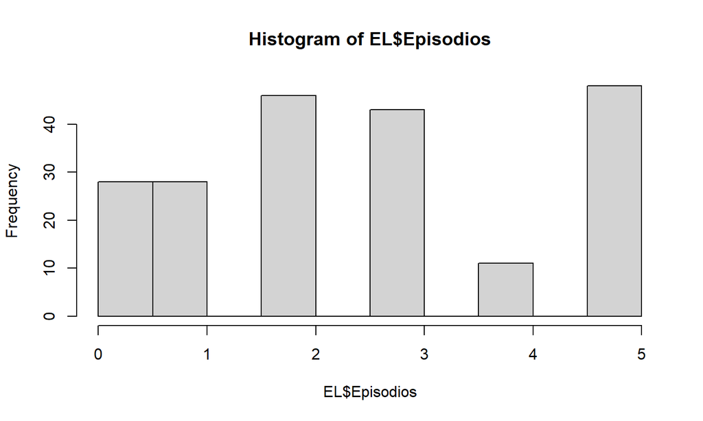

Según, lo observado podemos decir que podría ser una distribución Poisson. Por ello realizamos el valor esperado y la varianza de la variable X para saber si se asemejan en los parámetros.

```
## [1] 2.6128
```

```
## [1] 4.4558
```

Nos damos cuenta que el valor de la esperanza y la varianza no son iguales. Pero también, utilizamos la librería para poder graficar los bastones y darnos cuenta si coincide con el gráfico del histograma.

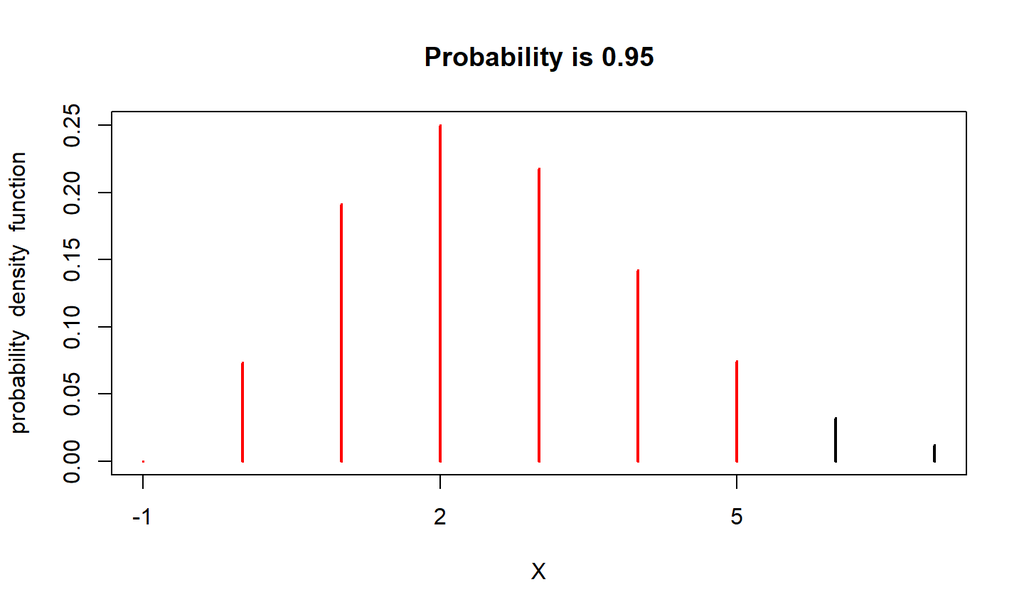

Por ello, podemos decir que los parámetros difieren. A pesar gráficamente si se asemeja a una distribución Poisson, para efectos de aplicación en el trabajo vamos a considerar a X como una Poisson.

### EVENTO 1 : Determinar la probabilidad de que un estudiante de la UTEC que haya experimentado como máximo 4 episodios de ansiedad o estrés en el periodo 2022-2.

P(X <= 4)

```
## [1] 0.8756071
```

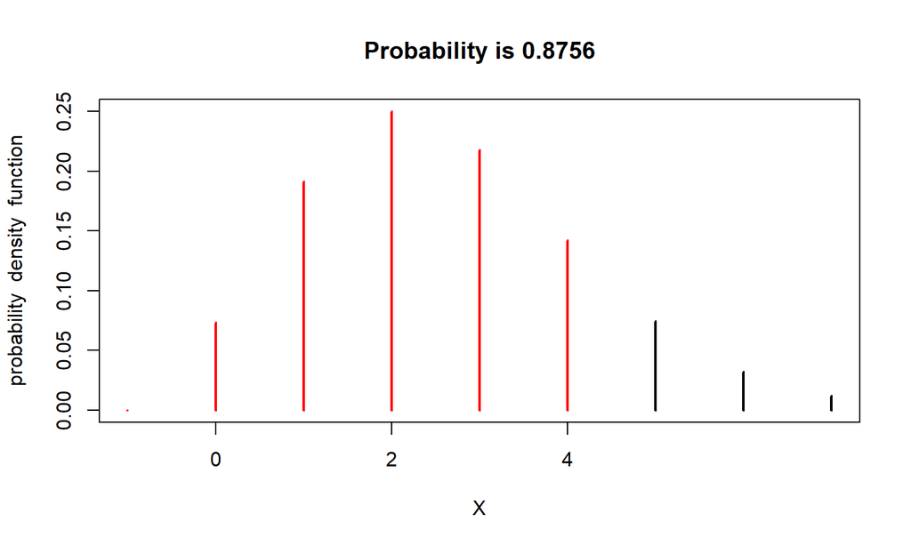

### EVENTO 2: Determinar la probabilidad de que un estudiante de la UTEC haya experimentado como máximo 2 episodios de ansiedad en el periodo 2022-2

P(X <= 2)

```
## [1] 0.515221
```

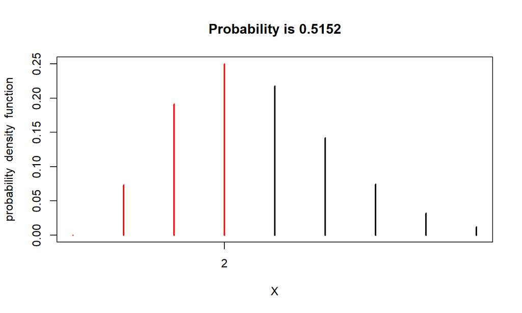

La probabilidad de que un estudiante del periodo del 2022-2 que ha experimentado como máximo 2 episodios de ansiedad o estrés es del *0.515221-> 51.5221%* ya que se esta suponiendo que es una Distribución poisson.

## Variable: Calidad de servicios en la asesorias de la universidad en el peridodo 2022-2

Rx = {0,1,2,3,4,5}

### Definimos la distribución que se usara

```
##   fi    pi
## 0  8  3.92
## 1  6  2.94
## 2 35 17.16
## 3 82 40.20
## 4 49 24.02
## 5 24 11.76
```

### Función de probabilidad

```
##
##      0      1      2      3      4      5
## 0.0392 0.0294 0.1716 0.4020 0.2402 0.1176
```

### Realizamos un histograma para saber al menos a que distribucion se podria asemejar

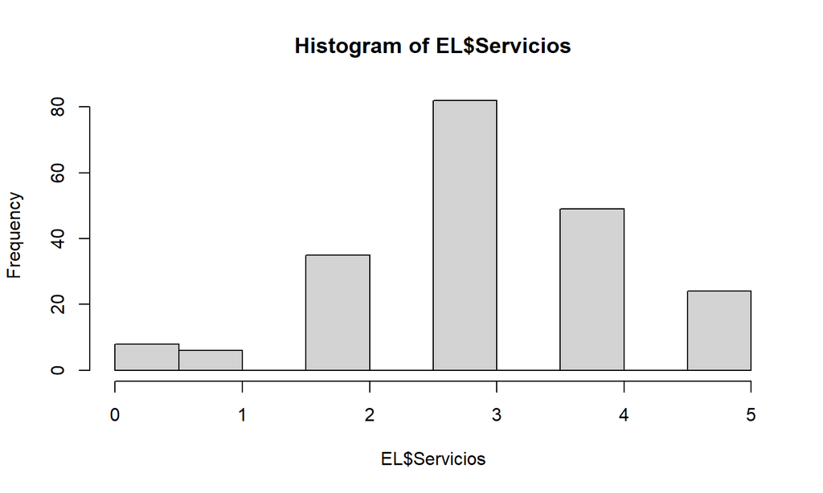

Según, lo observado podemos decir que podría ser una distribución Poisson. Por ello, realizamos el valor esperado y nuestra varianza de la variable X para saber si sus parametros son iguales.

```
## [1] 3.1274
```

```
## [1] 4.8622
```

E: valor esperado V: varianza

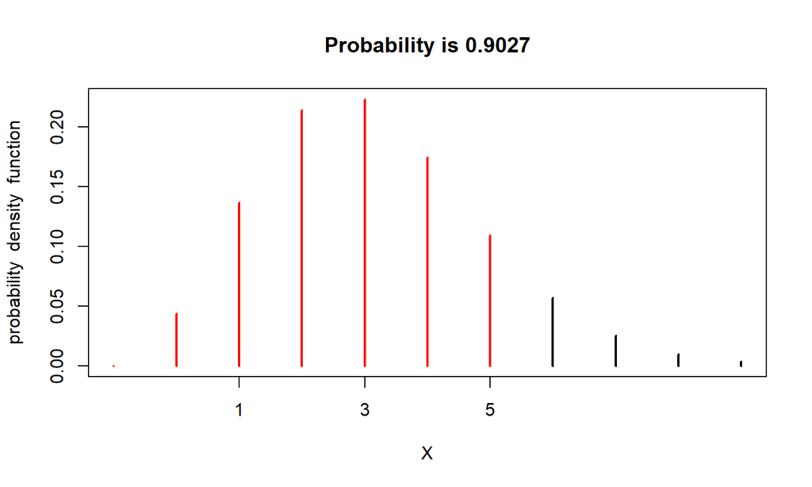

### EVENTO 1: Determinar la probabilidad de que los estudiante de UTEC estén satisfecho y totalmente satisfecho con el servicio de asesorías brindadas en el periodo 2022-2

Donde: 0-> totalmente insatisfecho 1-> Insatisfecho 2-> Poco satisfecho 3-> maso menos satisfecho 4-> satisfecho 5-> totalmente satisfecho

P(X>=4)

```
## [1] 0.3812859
```

[figure not shown]

La probabilidad de que los estudiantes de UTEC estén satisfechos y totalmente satisfecho es del *0.3812859->38.12859%*, ya que se esta suponiendo que es una Distribución poisson.

### EVENTO 2: Determinar la probabilidad de que los estudiantes de UTEC estén insatisfecho y totalmente insatisfecho, con el servicio de asesorías brindadas en el periodo 2022-2.

P(X<=2)

```
## [1] 0.395261
```

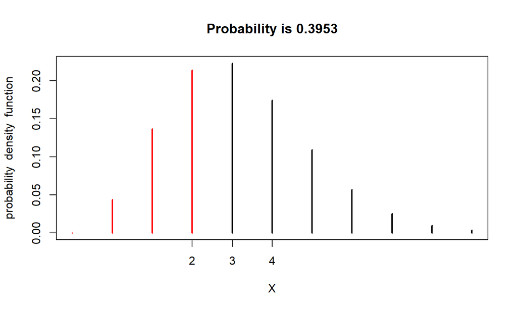

La probabilidad de que los estudiantes de UTEC estén insatisfechos y totalmente insatisfecho es del *0.395261->39.5261%*, ya que se esta suponiendo que es una Distribución poisson.

## 4 ANALISIS DE MODELOS DE PROBABILIDAD CONTINUA

1. Trabajamos con la variable “Matemáticas”

```
##
## Begin fitting distributions ---------------------------------------
```

```
## * fitting normal distribution ... OK
```

```
## * fitting Cauchy  distribution ... OK
```

```
## * fitting logistic distribution ... OK
```

```
## * fitting beta distribution ... failed
```

```
## * fitting exponential distribution ... OK
```

```
## * fitting chi-square distribution ... OK
```

```
## * fitting uniform distribution ... OK
```

```
## * fitting gamma distribution ... OK
```

```
## * fitting lognormal distribution ... OK
```

```
## * fitting Weibull distribution ... OK
```

```
## * fitting F-distribution ... OK
```

```
## * fitting Student's t-distribution ... OK
```

```
## * fitting Gompertz distribution ... failed
```

```
## * fitting triangular distribution ... failed
```

```
## End fitting distributions -----------------------------------------
```

```
##                 logL     AIC     BIC Chisq(value) Chisq(p) AD(value)    H(AD)
## Normal       -468.99  941.97  948.61         7.08     0.31      1.17 rejected
## Cauchy       -504.29 1012.58 1019.21        32.16     0.00      3.46 rejected
## Logistic     -470.29  944.59  951.23         8.72     0.19      1.26 rejected
## Exponential  -752.75  1507.5 1510.82       700.92     0.00     66.07 rejected
## Chi-square   -551.75 1105.49 1108.81       123.68     0.00     21.12     NULL
## Uniform         NULL    NULL    NULL        26.65     0.00       Inf     NULL
## Gamma        -475.74  955.48  962.12         8.80     0.18      1.76 rejected
## Lognormal    -481.21  966.43  973.07        10.72     0.10      2.31 rejected
## Weibull       -467.9  939.81  946.44         8.96     0.18      1.31 rejected
## F           -1006.86 2017.73 2024.36      2957.58     0.00    112.89     NULL
## Student     -1169.73 2341.47 2344.78      6815.81     0.00    204.73     NULL
##             KS(value)        H(KS)
## Normal           0.09 not rejected
## Cauchy           0.10     rejected
## Logistic         0.08 not rejected
## Exponential      0.49     rejected
## Chi-square       0.23     rejected
## Uniform          0.12     rejected
## Gamma            0.11     rejected
## Lognormal        0.12     rejected
## Weibull          0.09 not rejected
## F                0.66     rejected
## Student          0.81     rejected
```

```
##
## Chosen continuous distribution is: NA
## Fitted parameters are:
## [1] NA
```

Y: Promedio de notas en el curso de Matemáticas en el periodo 2022-2 Y~ N(14.731029; 2.410941^2)

```
## [1] 14.73103
```

```
## [1] 5.84127
```

```
## [1] 2.416872
```

Observamos que el promedio son iguales al que se muestra en el fit, pero la varianza son muy similares. Por ello, se utilizara los datos del fit para hacer nuestros cálculos.

P(Y >= 15)

```
## [1] 0.4555851
```

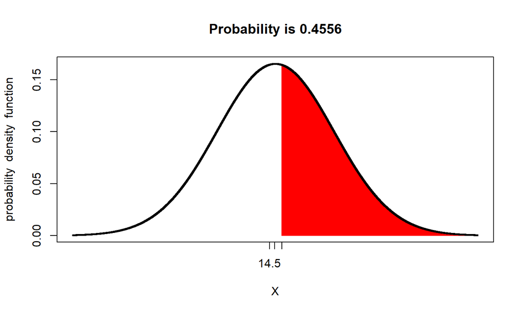

### 1) Trabajamos con la variable “Ciencias”

```
##
## Begin fitting distributions ---------------------------------------
```

```
## * fitting normal distribution ... OK
```

```
## * fitting Cauchy  distribution ... OK
```

```
## * fitting logistic distribution ... OK
```

```
## * fitting beta distribution ... failed
```

```
## * fitting exponential distribution ... OK
```

```
## * fitting chi-square distribution ... failed
```

```
## * fitting uniform distribution ... OK
```

```
## * fitting gamma distribution ... failed
```

```
## * fitting lognormal distribution ... failed
```

```
## * fitting Weibull distribution ... failed
```

```
## * fitting F-distribution ... failed
```

```
## * fitting Student's t-distribution ... OK
```

```
## * fitting Gompertz distribution ... failed
```

```
## * fitting triangular distribution ... failed
```

```
## End fitting distributions -----------------------------------------
```

```
##                 logL     AIC     BIC Chisq(value) Chisq(p) AD(value)    H(AD)
## Normal       -479.38  962.75  969.39        15.21     0.02      2.20 rejected
## Cauchy       -501.68 1007.36    1014        55.98     0.00      4.06 rejected
## Logistic     -470.99  945.98  952.62        19.98     0.00      1.86 rejected
## Exponential  -751.82 1505.64 1508.96       767.89     0.00       Inf rejected
## Uniform         NULL    NULL    NULL        32.40     0.00       Inf     NULL
## Student     -1165.63 2333.27 2336.59      7362.24     0.00    203.00     NULL
##             KS(value)        H(KS)
## Normal           0.11     rejected
## Cauchy           0.12     rejected
## Logistic         0.09 not rejected
## Exponential      0.50     rejected
## Uniform          0.14     rejected
## Student          0.81     rejected
```

```
##
## Chosen continuous distribution is: NA
## Fitted parameters are:
## [1] NA
```

Según lo mostrado usaremos la ecuación de la distribución logística que es la que se muestra: \[f(x) = 1 / (1 + exp(-(x - μ) / s))\] Donde: x: el valor para el cual se desea calcular la probabilidad acumulada. μ: el parámetro de ubicación (media) de la distribución logística. s: parámetro de escala de la distribución logística.

Por ello, tomaremos los datos de location y scale que nos da el fit.cont

Y: Promedio de notas en el curso de Ciencias en el periodo 2022-2 Y ~ L(14.790007, 1.366993)

## EVENTO: Determinar que tan probable es que un alumno halla obtenido como minimo 17 de nota en ciencias en el periodo 2022-2.

P(Y >= 17)

```
## [1] 0.165663
```

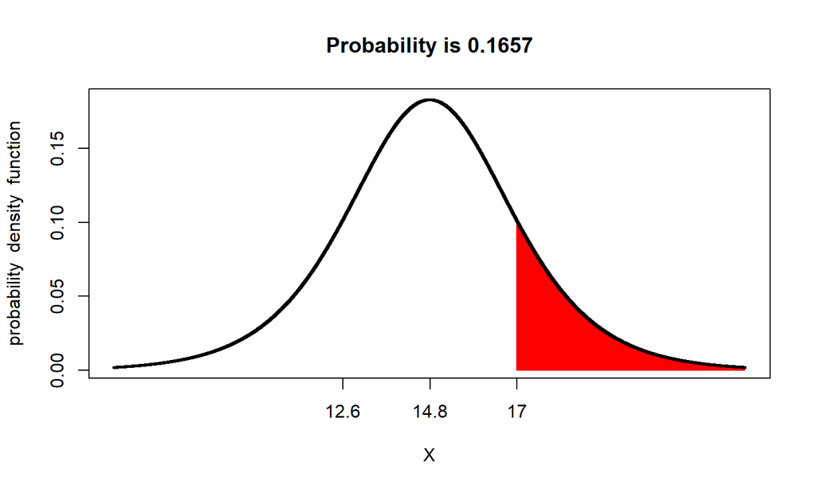

Observamos, que la probabilidad de que un alumno obtenga mayor a 17 de promedio en el curso de Ciencias es del 0.165663 -> 16.57% en una muestra de 204 alumnos en el periodo 2022-2 de la Utec.

## VI BIBLIOGRAFÍA

- Hattie, J. (2009). Visible learning: A synthesis of over 800 meta-analyses relating to achievement. Routledge.
- Cruz Zuluaga, M. N. (2016, junio). Factores que influyen en el rendimiento académico del estudiante. http://repositorio.esumer.edu.co/jspui/handle/esumer/363

\[GRACIAS 🌹 \]